# TCGA mutational signature analysis in Section 5

DongHyuk Lee and Bin Zhu

December 24, 2020

### 1. Data and preprocessing

The signature loading data file `TCGA_WES_sigProfiler_SBS_signatures_in_samples.csv` can be downloaded from [here](https://www.synapse.org/#!Synapse:syn11801497) (available as of December 2020). It contains signature loadings of the extracted signatures (descried in Section 5 of the manuscript). Based on the COSMIC (Catalog Of Somatic Mutations In Cancer) database V3 ([here](https://cancer.sanger.ac.uk/cosmic/signatures/SBS/index.tt)), we removed signatures (e.g., SBS27) which were possibly caused by sequencing artefacts. Note that SBS84, SBS85, …, SBS90 in COSMIC database are not available in the above loading data (modified on January 29, 2020). In addition, we removed the duplicated tumor samples.

```r
TCGA_loadings1 <- read.csv("TCGA_WES_sigProfiler_SBS_signatures_in_samples.csv")
### Available signatures without possible sequencing artefacts (from https://cancer.sanger.ac.uk/cosmic/signatures/SBS/index.tt, where SBS84 through SBS90 are not available in the loadings.)
Sig_names <- c(paste0("SBS", 1:6), paste0("SBS7", letters[1:4]), paste0("SBS", 8:9),
           paste0("SBS10", letters[1:2]), paste0("SBS", 11:16), paste0("SBS17", letters[1:2]),
           paste0("SBS", 18:26), paste0("SBS", 28:42), "SBS44")
### Remove duplicated samples
sampleID <- substring(TCGA_loadings1$Sample.Names, 1, 12)
sum(duplicated(sampleID)) ## 38 duplicatesd
```

```
## [1] 38
```

```r
TCGA_loadings <- TCGA_loadings1[!duplicated(sampleID), c("Cancer.Types", Sig_names)]
head(TCGA_loadings)
```

```
##   Cancer.Types SBS1 SBS2 SBS3 SBS4 SBS5 SBS6 SBS7a SBS7b SBS7c SBS7d SBS8 SBS9
## 1          AML    3    0    0    0    0    0     0     0     0     0    0    0
## 2          AML    4    0    0    0    7    0     0     0     0     0    0    0
## 3          AML    0    0    0    0    0    0     0     0     0     0    0    0
## 4          AML   12    0    0    0    5    0     0     0     0     0    0    0
## 5          AML   40    0    0    0  337    0     0     0     0     0    0    0
## 6          AML   33    0    0    0  171    0     0     0     0     0    0    0
##   SBS10a SBS10b SBS11 SBS12 SBS13 SBS14 SBS15 SBS16 SBS17a SBS17b SBS18 SBS19
## 1      0      0     0     0     0     0     0     0      0      0     0     6
## 2      0      0     0     0     0     0     0     0      0      0     0     0
## 3      0      0     0     0     0     0     0     0      0      0     0     0
## 4      0      0     0     0     0     0     0     0      0      0     0     0
## 5      0      0     0     0     0     0     0     0      0      0     0     0
## 6      0      0     0     0     0     0     0     0      0      0     0     0
##   SBS20 SBS21 SBS22 SBS23 SBS24 SBS25 SBS26 SBS28 SBS29 SBS30 SBS31 SBS32 SBS33
## 1     0     0     0     0     0     0     0     0     0     0     0     0     0
## 2     0     0     0     0     0     0     0     0     0     0     0     0     0
## 3     0     0     0     0     0     0     0     0     0     0     0     0     0
## 4     0     0     0     0     0     0     0     0     0     0     0     0     0
## 5     0     0     0     0     0     0     0     0     0     0     0     0     0
## 6     0     0     0     0     0     0     0     0     0     0     0     0     0
##   SBS34 SBS35 SBS36 SBS37 SBS38 SBS39 SBS40 SBS41 SBS42 SBS44
## 1     0     0     0     0     0     0     0     0     6     0
## 2     0     0     0     0     0     0     7     0     0     0
## 3     0     0     0     0     0     0     0     0     0     0
## 4     0     0     0     0     0     0     0     0    34     0
## 5     0     0     0     0     0     0     0     0   293     0
## 6     0     0     0     0     0     0     0     0   135     0
```

```r
table(TCGA_loadings$Cancer.Types)
```

```
##
##            Adrenal-neoplasm                         AML
##                          91                         139
##             Biliary-AdenoCa               Breast-cancer
##                          36                         929
##                   Cervix-CA                     CNS-GBM
##                         269                         360
##            ColoRect-AdenoCa                        DLBC
##                         494                         502
##                 Eso-AdenoCa                Eye-Melanoma
##                         182                          80
##                    Head-SCC                Kidney-ChRCC
##                         463                          50
##            Kidney-Papillary                  Kidney-RCC
##                         250                         333
##                   Liver-HCC                Lung-AdenoCa
##                         311                         528
##                    Lung-SCC                  Lymph-BNHL
##                         427                          31
##    Mesothelium-Mesothelioma               Ovary-AdenoCa
##                          82                         385
##                Panc-AdenoCa            Pheochromocytoma
##                         174                         177
##               Prost-AdenoCa                     Sarcoma
##                         484                         206
##               Skin-Melanoma             Stomach-AdenoCa
##                         412                         401
##                   Testis-Ca                 Thy-AdenoCa
##                         144                         472
##                     Thymoma Transitional-cell-carcinoma
##                         123                         389
##                         UCS              Uterus-AdenoCa
##                          57                         474
```

In Section 5 of the manuscript, we focused on three gastrointestinal cancers: colorectal adenocarcinoma, esophageal adenocarcinoma and stomach adenocarcinoma. The following codes demonstrate the preprocessing steps to exclude signatures 1) when total loading counts are less than 10 and/or 2) when the number of subjects with non-zero loading counts is less than 5% of the study size for each cancer type. We also included processed datasets, `Reduced_ColoRect-AdenoCa.csv` for colorectal adenocarcinoma, `Reduced_Eso-AdenoCa.csv`for esophageal adenocarcinoma, and `Reduced_Stomach-AdenoCa.csv` for stomach adenocarcinoma.

```r
### Extract gastrointestinal cancers
Gastro <- c("ColoRect-AdenoCa", "Eso-AdenoCa", "Stomach-AdenoCa")
### Total counts (Tcnt) and Nonzero counts (Ncnt) of signatures across cancer type
Tcnt <- NULL
Ncnt <- NULL
for(typ in Gastro){
  Tcnt <- rbind(Tcnt, colSums(TCGA_loadings[TCGA_loadings$Cancer.Types == typ,-1]))
  Ncnt <- rbind(Ncnt, apply(TCGA_loadings[TCGA_loadings$Cancer.Types == typ,-1], 2, function(x) sum(x != 0)))
}
### Total loading counts per each cancer type
Tcnt.D <- cbind.data.frame(table(TCGA_loadings$Cancer.Types[TCGA_loadings$Cancer.Types %in% Gastro]), Tcnt)
Tcnt.D
```

```
##               Var1 Freq  SBS1 SBS2 SBS3 SBS4  SBS5 SBS6 SBS7a SBS7b SBS7c SBS7d
## 1 ColoRect-AdenoCa  494 63378  528  510    0 66516    0     0     0     0     0
## 2      Eso-AdenoCa  182  6690 2433 1799  701 20179 1355     0     0     0     0
## 3  Stomach-AdenoCa  401 46186 1108    0    0 64121 5505     0     0     0     0
##   SBS8 SBS9 SBS10a SBS10b SBS11 SBS12 SBS13 SBS14 SBS15 SBS16 SBS17a SBS17b
## 1    0  277  20336  22976     0     0   254     0 16170     0    182    382
## 2   18    0      1     19     0     0  3068     0    15   688   1110   2324
## 3    0    0   1618   2754     0     0   920  1791 15160     0   2584   5549
##   SBS18 SBS19 SBS20 SBS21 SBS22 SBS23 SBS24 SBS25 SBS26 SBS28 SBS29 SBS30 SBS31
## 1     0     0  3553     0     0     0     0     0   288     0     0  2139     0
## 2  1954     0     0     0     0     0     0     0     0     0     0     0     0
## 3     0     0 11029  3763    83     0     0     0     0   105     0    15     0
##   SBS32 SBS33 SBS34 SBS35 SBS36 SBS37 SBS38 SBS39 SBS40 SBS41 SBS42 SBS44
## 1     0     0     0     0     0     0     0     0 17594     0     0 29367
## 2     0     0     0     0     0     0     0     0     0     0     4     4
## 3     0     0     0     0     0     0     0     0 11715     0    18     0
```

```r
### The number of subjects with non-zero loading counts
Ncnt.D <- cbind.data.frame(table(TCGA_loadings$Cancer.Types[TCGA_loadings$Cancer.Types %in% Gastro]), Ncnt)
Ncnt.D
```

```
##               Var1 Freq SBS1 SBS2 SBS3 SBS4 SBS5 SBS6 SBS7a SBS7b SBS7c SBS7d
## 1 ColoRect-AdenoCa  494  493   37    8    0  426    0     0     0     0     0
## 2      Eso-AdenoCa  182  178  100   24    2  179    4     0     0     0     0
## 3  Stomach-AdenoCa  401  393  111    0    0  359    9     0     0     0     0
##   SBS8 SBS9 SBS10a SBS10b SBS11 SBS12 SBS13 SBS14 SBS15 SBS16 SBS17a SBS17b
## 1    0    6      8     11     0     0    30     0    44     0     23     27
## 2    1    0      1      3     0     0   100     0     1    14     57     59
## 3    0    0      4      8     0     0    90     2    60     0    137    159
##   SBS18 SBS19 SBS20 SBS21 SBS22 SBS23 SBS24 SBS25 SBS26 SBS28 SBS29 SBS30 SBS31
## 1     0     0    16     0     0     0     0     0     1     0     0    23     0
## 2    46     0     0     0     0     0     0     0     0     0     0     0     0
## 3     0     0    57     3     1     0     0     0     0     1     0     1     0
##   SBS32 SBS33 SBS34 SBS35 SBS36 SBS37 SBS38 SBS39 SBS40 SBS41 SBS42 SBS44
## 1     0     0     0     0     0     0     0     0   225     0     0    46
## 2     0     0     0     0     0     0     0     0     0     0     1     1
## 3     0     0     0     0     0     0     0     0   168     0     1     0
```

```r
### Extract columns (signatures) when total loading counts (Tcnt.D) > 10 and non-zero loading counts (Ncnt.D) > 0.05*(# of samples)
## colorectal adenocarcinoma
Sigs <- names(Tcnt.D)[-(1:2)][Tcnt.D[1, -(1:2)] > 10 & Ncnt.D[1, -(1:2)] > 0.05*Ncnt.D$Freq[1]]
Colo <- TCGA_loadings[TCGA_loadings$Cancer.Types == Gastro[1], Sigs]
head(Colo)
```

```
##      SBS1 SBS2 SBS5 SBS13 SBS15 SBS17b SBS40 SBS44
## 1830   75    0  107     0     0      0     0     0
## 1831   57    0   22     0     0      0    66     0
## 1832   77    0  104     0     0      0     0     0
## 1833   90    0   31     0     0     13   122     0
## 1834   57    0   71     0     0      0     0     0
## 1835 1104    0  629     0     0      0     0   805
```

```r
Colo_chk <- read.csv("Reduced_ColoRect-AdenoCa.csv")
#head(Colo_chk)
sum(abs(Colo_chk - Colo))
```

```
## [1] 0
```

```r
## esophageal adenocarcinoma
Sigs <- names(Tcnt.D)[-(1:2)][Tcnt.D[2, -(1:2)] > 10 & Ncnt.D[2, -(1:2)] > 0.05*Ncnt.D$Freq[2]]
Eso <- TCGA_loadings[TCGA_loadings$Cancer.Types == Gastro[2], Sigs]
head(Eso)
```

```
##      SBS1 SBS2 SBS3 SBS5 SBS13 SBS16 SBS17a SBS17b SBS18
## 2838   90   35    0  222    12     0     24     34     0
## 2839   28   10   57   51     6     0     11     16     0
## 2840   48    0    0  151     0     0     52     51     0
## 2841   24    4    0  124     8     0      0      0     0
## 2842   32   15   70   69    22     0     42     59     0
## 2843   33    0   97   98     0     0     42     49     0
```

```r
Eso_chk <- read.csv("Reduced_Eso-AdenoCa.csv")
#head(Eso_chk)
sum(abs(Eso_chk - Eso))
```

```
## [1] 0
```

```r
## stomach adenocarcinoma
Sigs <- names(Tcnt.D)[-(1:2)][Tcnt.D[3, -(1:2)] > 10 & Ncnt.D[3, -(1:2)] > 0.05*Ncnt.D$Freq[3]]
Stom <- TCGA_loadings[TCGA_loadings$Cancer.Types == Gastro[3], Sigs]
head(Stom)
```

```
##      SBS1 SBS2 SBS5 SBS13 SBS15 SBS17a SBS17b SBS20 SBS40
## 7423   26    8   24    14     0      0      0     0   125
## 7424   45    0   98     0     0      0      0     0     0
## 7425  328    0  728     0   137      0      0   229     0
## 7426   53   39  134     0     0     36     40     0   194
## 7427  262    0  232     0    86      0      0   123     0
## 7428  122    0  150     0     0     13     30     0     0
```

```r
Stom_chk <- read.csv("Reduced_Stomach-AdenoCa.csv")
#head(Stom_chk)
sum(abs(Stom_chk - Stom))
```

```
## [1] 0
```

### 2. Association tests

First we need to install `SKIT` package in the following way.

```r
### For Windows
# install.packages("SKIT_0.0.2.zip", repos = NULL)
### or
# install.packages("SKIT_0.0.2.tar.gz", repos = NULL, type = "source")
### For UNIX
# install.packages("SKIT_0.0.2.tar.gz", repos = NULL)
library(SKIT)
```

Here, we present results for one cancer type, colorectal adenocarcinoma, but results corresponding to other cancer types can be obtained similarly as described in Section 2.1.

```r
### All possible combinations of signatures of colorectal adenocarcinoma
Allpairs <- combn(names(Colo), 2)
ncol(Allpairs)
```

```
## [1] 28
```

```r
### Normalization with respect to total counts (Section 2.2 and Section 5 in the manuscript)
Colo_norm <- t(apply(Colo,1, function(x){x/sum(x)}))
Colo_norm[is.nan(Colo_norm)] <- 0
```

In the manuscript, we used $B = 30,000$ bootstrap samples to distinguish small scale $p$-values. Since the tests of all possible combinations (28 combinations) are time consuming, we show the result of one signature pair (signature 2 and signature 17b) as an example. The entire results are provided in `online_supplements.zip` file. To replicate the same results, please use `set.seed(1)` for all combinations regardless of cancer types.

```r
Allpairs[,11]
```

```
## [1] "SBS2"   "SBS17b"
```

```r
tmp <- Colo_norm[, Allpairs[,11]]
x <- tmp[,1]
y <- tmp[,2]
set.seed(1)
system.time( re <- skit(x, y, nboot = 30000) )
```

```
##    user  system elapsed
##   10.27    0.00   10.49
```

```r
re
```

```
## $tests
##            T           T1           T2           T3           T4
## 0.0152450052 0.0001464263 0.0011506357 0.0014416390 0.0125063042
##
## $pvalues
##            T           T1           T2           T3           T4
## 0.0005999800 0.0001999933 0.0010666311 0.0001333289 0.0009666344
##
## $bandwidth.obs
## [1] 0.02002535
```

The computation is conducted in a Dell Latitude 7490 laptop with Intel(R) Core(TM) i7-8650 CPU @ 1.90GHz. We would like to point out that computing time may vary depending on the sample size as well as the number of non-zero elements. `skit()` function returns 1) `re$tests` which contains 5 test statistics (the overall SKIT test statistic (`T`) and its components (`T1`, `T2`, `T3`, `T4`)); 2) `re$pvalues` p-values corresponding to test statistics in `re$tests`; and 3) `re$bandwidth.obs` the bandwidth of kernel density (see Section 3 for details).

We have conducted association tests for all possible pairs and `SKIT_Result_ColoRect-AdenoCa.csv` contains test results of all 28 combinations for colorectal adenocarcinoma.

```r
Colo_entire <- read.csv("SKIT_Result_ColoRect-AdenoCa.csv", stringsAsFactors = FALSE)
Colo_entire[10:14,]#[Colo_entire$Sig1 == "SBS2" & Colo_entire$Sig2 == "SBS17b",]
```

```
##    Sig1   Sig2        bws           T          T1          T2          T3
## 10 SBS2  SBS15 0.04219079 0.000734352 0.000044500 0.000207953 0.000085000
## 11 SBS2 SBS17b 0.02002535 0.015245005 0.000146426 0.001150636 0.001441639
## 12 SBS2  SBS40 0.03460914 0.005253901 0.000002980 0.000137465 0.000494344
## 13 SBS2  SBS44 0.02280418 0.001615289 0.000048600 0.000322957 0.000162798
## 14 SBS5  SBS13 0.06212510 0.002599629 0.000040100 0.000333069 0.000265385
##             T4          p          p1          p2          p3          p4
## 10 0.000396944 0.38228726 0.044465184 0.077164095 0.340855305 0.612279591
## 11 0.012506304 0.00059998 0.000199993 0.001066631 0.000133329 0.000966634
## 12 0.004619115 0.30795640 0.766874438 0.625612480 0.348688377 0.269291024
## 13 0.001080892 0.59834672 0.039332022 0.096563448 0.323855871 0.745341822
## 14 0.001961042 0.22925903 0.085030499 0.403486550 0.029865671 0.253024899
```

Each row of `Colo_entire` shows `skit()` result for a pair of signatures. For example, the 11th row presents the results for the pair (SBS2, SBS17b). The entire results can be obtained via the following code, but we commented out due to long computation time.

```r
# Colo_re <- NULL
# for(i in 1:ncol(Allpairs)){
#   tmp <- Colo_norm[, Allpairs[,i]]
#   x <- tmp[,1]
#   y <- tmp[,2]
#   set.seed(1)
#   re <- skit(x, y, nboot = 30000)
#   tmp1 <- matrix(c(re$bandwidth.obs, re$tests, re$pvalues), nrow = 1)
#   colnames(tmp1) <- c("bws", "T", paste0("T", 1:4), "p", paste0("p", 1:4))
#   Colo_re <- rbind(Colo_re, tmp1)
# }
# Colo_re
```

#### 2.1 Test results for other cancer type

`skit()` results of the signature pair 2 and 17b from esophageal and stomach adenocarcinoma, can be obtained from the following codes. `SKIT_Result_Eso-AdenoCa.csv` and `SKIT_Result_Stomach-AdenoCa.csv` contain test results of all combinations.

```r
Eso_norm <- t(apply(Eso,1, function(x){x/sum(x)}))
Eso_norm[is.nan(Eso_norm)] <- 0
Allpairs <- combn(names(Eso), 2)
tmp <- Eso_norm[, Allpairs[,14]]
x <- tmp[,1]
y <- tmp[,2]
set.seed(1)
re <- skit(x, y, nboot = 30000)
Eso_entire <- read.csv("SKIT_Result_Eso-AdenoCa.csv", stringsAsFactors = FALSE)
re
```

```
## $tests
##           T          T1          T2          T3          T4
## 0.160111079 0.001243369 0.015660921 0.012631148 0.130575640
##
## $pvalues
##          T         T1         T2         T3         T4
## 0.01306623 0.04166528 0.01676611 0.01286624 0.02026599
##
## $bandwidth.obs
## [1] 0.0284229
```

```r
Eso_entire[14,]
```

```
##    Sig1   Sig2       bws         T          T1         T2         T3        T4
## 14 SBS2 SBS17b 0.0284229 0.1601111 0.001243369 0.01566092 0.01263115 0.1305756
##             p         p1         p2         p3         p4
## 14 0.01306623 0.04166528 0.01676611 0.01286624 0.02026599
```

```r
Stom_norm <- t(apply(Stom,1, function(x){x/sum(x)}))
Stom_norm[is.nan(Stom_norm)] <- 0
Allpairs <- combn(names(Stom_chk), 2)
tmp <- Stom_norm[, Allpairs[,13]]
x <- tmp[,1]
y <- tmp[,2]
set.seed(1)
re <- skit(x, y, nboot = 30000)
Stom_entire <- read.csv("SKIT_Result_Stomach-AdenoCa.csv", stringsAsFactors = FALSE)
re
```

```
## $tests
##            T           T1           T2           T3           T4
## 0.0603857525 0.0003036399 0.0061854177 0.0037997059 0.0500969891
##
## $pvalues
##           T          T1          T2          T3          T4
## 0.005166494 0.110229659 0.007699743 0.042865238 0.005099830
##
## $bandwidth.obs
## [1] 0.03205867
```

```r
Stom_entire[13,]
```

```
##    Sig1   Sig2        bws          T         T1          T2          T3
## 13 SBS2 SBS17b 0.03205867 0.06038575 0.00030364 0.006185418 0.003799706
##            T4           p        p1          p2         p3         p4
## 13 0.05009699 0.005166494 0.1102297 0.007699743 0.04286524 0.00509983
```

### 3. Creating Table 2

The following codes are used to generate Table 2.

```r
Eso_entire <- read.csv("SKIT_Result_Eso-AdenoCa.csv", stringsAsFactors = FALSE)
Stom_entire <- read.csv("SKIT_Result_Stomach-AdenoCa.csv", stringsAsFactors = FALSE)
Skit_Colo_FDR <- cbind(Colo_entire[,1:2], round(Colo_entire[,-(1:3)],4),
                       BH = round(p.adjust(Colo_entire$p, method = "BH"), 4),
                       BH1 = round(p.adjust(Colo_entire$p1, method = "BH"), 4),
                       BH2 = round(p.adjust(Colo_entire$p2, method = "BH"), 4),
                       BH3 = round(p.adjust(Colo_entire$p3, method = "BH"), 4),
                       BH4 = round(p.adjust(Colo_entire$p4, method = "BH"), 4))
Skit_Eso_FDR <- cbind(Eso_entire[,1:2], round(Eso_entire[,-(1:3)],4),
                       BH = round(p.adjust(Eso_entire$p, method = "BH"), 4),
                       BH1 = round(p.adjust(Eso_entire$p1, method = "BH"), 4),
                       BH2 = round(p.adjust(Eso_entire$p2, method = "BH"), 4),
                       BH3 = round(p.adjust(Eso_entire$p3, method = "BH"), 4),
                       BH4 = round(p.adjust(Eso_entire$p4, method = "BH"), 4))
Skit_Stom_FDR <- cbind(Stom_entire[,1:2], round(Stom_entire[,-(1:3)],4),
                      BH = round(p.adjust(Stom_entire$p, method = "BH"), 4),
                      BH1 = round(p.adjust(Stom_entire$p1, method = "BH"), 4),
                      BH2 = round(p.adjust(Stom_entire$p2, method = "BH"), 4),
                      BH3 = round(p.adjust(Stom_entire$p3, method = "BH"), 4),
                      BH4 = round(p.adjust(Stom_entire$p4, method = "BH"), 4))
Tab2 <- rbind(
          Skit_Colo_FDR[Skit_Colo_FDR$Sig1 %in% c("SBS2", "SBS13") &
                        Skit_Colo_FDR$Sig2 %in% c("SBS17a", "SBS17b"),
                        c("Sig1", "Sig2", "BH", "BH1", "BH2", "BH3", "BH4")],
          Skit_Eso_FDR[Skit_Eso_FDR$Sig1 %in% c("SBS2", "SBS13") &
                         Skit_Eso_FDR$Sig2 %in% c("SBS17a", "SBS17b"),
                        c("Sig1", "Sig2", "BH", "BH1", "BH2", "BH3", "BH4")],
          Skit_Stom_FDR[Skit_Stom_FDR$Sig1 %in% c("SBS2", "SBS13") &
                        Skit_Stom_FDR$Sig2 %in% c("SBS17a", "SBS17b"),
                        c("Sig1", "Sig2", "BH", "BH1", "BH2", "BH3", "BH4")]
        )
names(Tab2) <- c("Sig1", "Sig2", "T", "T1", "T2", "T3", "T4")
row.names(Tab2) <- NULL
Tab2 <- cbind(Type = c("colorectal", "", "esophageal", "", "", "", "stomach", "", "", ""), Tab2)
library(knitr)
kable(Tab2, caption = "Table 2. FDR adjusted p-values of all active pairs between 17a/b and
      APOBEC-mediated signatures for gastrointestinal cancers.")
```

Table 2. FDR adjusted p-values of all active pairs between 17a/b and APOBEC-mediated signatures for gastrointestinal cancers.

| Type | Sig1 | Sig2 | T | T1 | T2 | T3 | T4 |
| --- | --- | --- | --- | --- | --- | --- | --- |
| colorectal | SBS2 | SBS17b | 0.0019 | 0.0014 | 0.0031 | 0.0009 | 0.0034 |
|  | SBS13 | SBS17b | 0.0320 | 0.0356 | 0.0179 | 0.0561 | 0.0387 |
| esophageal | SBS2 | SBS17a | 0.0351 | 0.1310 | 0.0239 | 0.1372 | 0.0486 |
|  | SBS2 | SBS17b | 0.0336 | 0.1310 | 0.0377 | 0.0694 | 0.0486 |
|  | SBS13 | SBS17a | 0.0081 | 0.1310 | 0.0037 | 0.1372 | 0.0104 |
|  | SBS13 | SBS17b | 0.0098 | 0.1310 | 0.0063 | 0.0694 | 0.0176 |
| stomach | SBS2 | SBS17a | 0.0354 | 0.3102 | 0.0554 | 0.1457 | 0.0394 |
|  | SBS2 | SBS17b | 0.0085 | 0.1804 | 0.0132 | 0.0735 | 0.0097 |
|  | SBS13 | SBS17a | 0.2112 | 0.3480 | 0.1839 | 0.3071 | 0.2269 |
|  | SBS13 | SBS17b | 0.0423 | 0.1892 | 0.1084 | 0.1605 | 0.0414 |

### 4. Generating Figure S.3

For the signature pairs 2 and 17b, we provide the following scatterplots to investigate in detail.

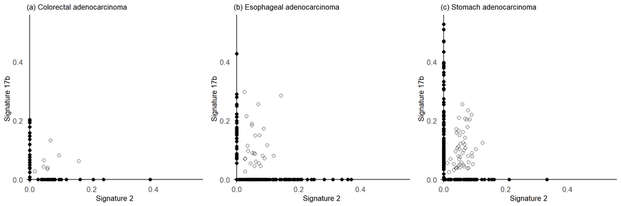

```r
library(ggplot2)
library(gridExtra)
# Colorectal adenocarcinoma 2 and 17b
x <- Colo_norm[, "SBS2"]
y <- Colo_norm[, "SBS17b"]
Colo_D <- data.frame(x,y)
Colo_D$idx <- factor(ifelse(Colo_D$x != 0 & Colo_D$y != 0, 1, 0))
Colo217b <- ggplot(data = Colo_D, aes(x = x, y = y, shape = idx)) + geom_point(size = 2) +
    xlab("Signature 2") + ylab("Signature 17b") +
    scale_shape_manual(values = c(19, 1)) + ggtitle("(a) Colorectal adenocarcinoma") +
    theme(legend.position = "none", panel.background = element_blank(),
          axis.line = element_blank(), axis.ticks = element_blank(),
          axis.title = element_text(size = 10), axis.text = element_text(size = 10),
          plot.title = element_text(size = 10, hjust = 0)) +
    geom_hline(yintercept = 0) + geom_vline(xintercept = 0) +
    scale_x_continuous(limits = c(0, 0.55), expand = c(0, 0.01)) +
    scale_y_continuous(limits = c(0, 0.55), expand = c(0, 0.01))
# Esophageal adenocarcinoma 2 and 17b
Eso_norm <- t(apply(Eso,1, function(x){x/sum(x)}))
Eso_norm[is.nan(Eso_norm)] <- 0
x <- Eso_norm[, "SBS2"]
y <- Eso_norm[, "SBS17b"]
Eso_D <- data.frame(x,y)
Eso_D$idx <- factor(ifelse(Eso_D$x != 0 & Eso_D$y != 0, 1, 0))
Eso217b <- ggplot(data = Eso_D, aes(x = x, y = y, shape = idx)) + geom_point(size = 2) +
    xlab("Signature 2") + ylab("Signature 17b") +
    scale_shape_manual(values = c(19, 1)) + ggtitle("(b) Esophageal adenocarcinoma") +
    theme(legend.position = "none", panel.background = element_blank(),
          axis.line = element_blank(), axis.ticks = element_blank(),
          axis.title = element_text(size = 10), axis.text = element_text(size = 10),
          plot.title = element_text(size = 10, hjust = 0)) +
    geom_hline(yintercept = 0) + geom_vline(xintercept = 0) +
    scale_x_continuous(limits = c(0, 0.55), expand = c(0, 0.01)) +
    scale_y_continuous(limits = c(0, 0.55), expand = c(0, 0.01))
# Stomach adenocarcinoma 2 and 17b
Stom_norm <- t(apply(Stom,1, function(x){x/sum(x)}))
Stom_norm[is.nan(Stom_norm)] <- 0
x <- Stom_norm[, "SBS2"]
y <- Stom_norm[, "SBS17b"]
Stom_D <- data.frame(x,y)
Stom_D$idx <- factor(ifelse(Stom_D$x != 0 & Stom_D$y != 0, 1, 0))
Stom217b <- ggplot(data = Stom_D, aes(x = x, y = y, shape = idx)) + geom_point(size = 2) +
    xlab("Signature 2") + ylab("Signature 17b") +
    scale_shape_manual(values = c(19, 1)) + ggtitle("(c) Stomach adenocarcinoma") +
    theme(legend.position = "none", panel.background = element_blank(),
          axis.line = element_blank(), axis.ticks = element_blank(),
          axis.title = element_text(size = 10), axis.text = element_text(size = 10),
          plot.title = element_text(size = 10, hjust = 0)) +
    geom_hline(yintercept = 0) + geom_vline(xintercept = 0) +
    scale_x_continuous(limits = c(0, 0.55), expand = c(0, 0.01)) +
    scale_y_continuous(limits = c(0, 0.55), expand = c(0, 0.01))
grid.arrange(Colo217b, Eso217b, Stom217b, nrow = 1)
```

### 5. Making Figure 4

The following plots are modification from the one found in http://jokergoo.github.io/blog/html/large_matrix_circular.html. The source code of function `cir.corr()` can be found in “cir.corr.R” but please note that the `circlize` package is required.

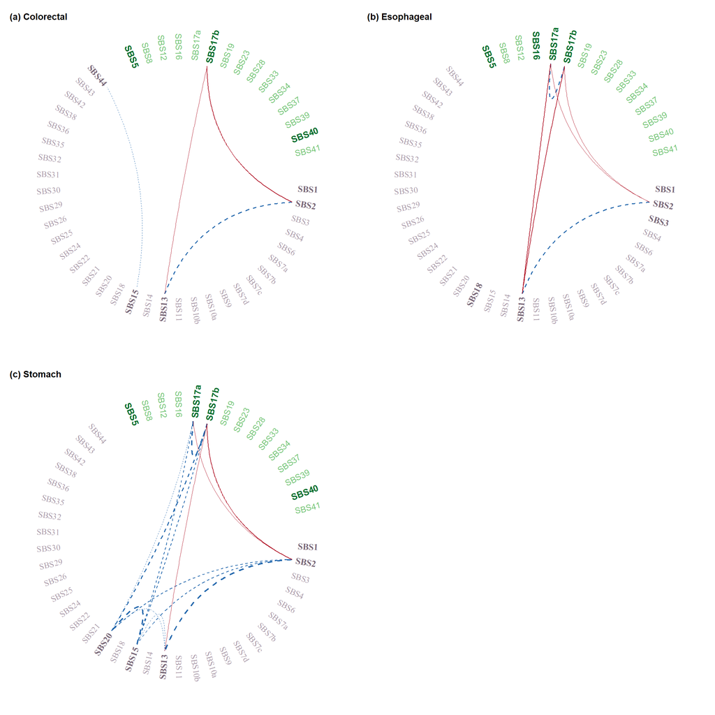

```r
source("cir.corr.R")
library(circlize)
par(mfrow = c(2,2))
cir.corr("Colo")
cir.corr("Eso")
cir.corr("Stom")
```